# R VISUALIZATION

# I. Introduction

The report’s objective is to describe a dataset named “game” (Video Game Sales). We separate the report into two parts, including Exploratory Data Analysis and Data Visualization. In the first part, we summarize and discuss the dataset, consisting of subsections such as “About the dataset”, “Descriptive Statistics”, and “Handling Data”. In the second part, we dig in the characteristics of each variable and consider their relationships through visualization.

In the report, we show off our reflection of the lecture by combining three main parts: Basic R (about calculation and variables), Data manipulation (Using dplyr), and Data visualization (Using ggplot and theme).

# II. Exploratory Data Analysis

## 1. About the dataset

```r
table<-data.frame(
  Order=c(1,2,3,4,5,6,7,8,9,10,11),
  Variable_Name=c("Rank","Name", "Platform","Year", "Genre", "Publisher", "NA_Sales", "EU_Sales","JP_Sales", "Other_Sales", "Global_Sales"),
  Type= c("Factor","Factor", "Factor", "Factor", "Factor", "Factor", "Numeric", "Numeric", "Numeric", "Numeric", "Numeric"),
  Label_Description=c("The rank in total sales of the game","The name of the game", "The platform where the game was built in", "The year when the game was released", "The genre of the game", "The publisher of the game", "Sales of the game in North America", "Sales of the game in EU", "Sales of the game in Japan","Sales of the game in Other place", "Sales of the game in total")
)
kbl(table, caption = "Data “game” (Video Game Sales) label and description")%>%
row_spec(row =0, bold= TRUE, color = "black", background = "#F9EBEA") %>%
kable_styling(bootstrap_options = c("striped", "hover", "bordered"), full_width = F, position = "center")
```

Data “game” (Video Game Sales) label and description

| Order | Variable_Name | Type | Label_Description |
| --- | --- | --- | --- |
| 1 | Rank | Factor | The rank in total sales of the game |
| 2 | Name | Factor | The name of the game |
| 3 | Platform | Factor | The platform where the game was built in |
| 4 | Year | Factor | The year when the game was released |
| 5 | Genre | Factor | The genre of the game |
| 6 | Publisher | Factor | The publisher of the game |
| 7 | NA_Sales | Numeric | Sales of the game in North America |
| 8 | EU_Sales | Numeric | Sales of the game in EU |
| 9 | JP_Sales | Numeric | Sales of the game in Japan |
| 10 | Other_Sales | Numeric | Sales of the game in Other place |
| 11 | Global_Sales | Numeric | Sales of the game in total |

The dataset “game” is first generated by the raw data in [vgchartz](https://www.vgchartz.com/) and then it was collected and formatted in kaggle. It was first posted in kaggle in 2016, then was continuously updated till 2020. The dataset was about the new game released with some additional information, presented by 11 variables and 16,598 observations. The table 1 depicts variables’ name, type and short description. As can be seen from the table, there are 6 categorical variables and 5 numeric variables.

## 2. Descriptive Statistics

```r
table1<-data.frame(
  Numeric_variables=c("Sales of the game in North America", "Sales of the game in EU", "Sales of the game in Japan","Sales of the game in Other place", "Sales of the game in total"),
  Min=c("0","0","0","0","0.01"),
  Mean=c("0.2647","0.1467","0.07778","0.04806","0.5374"),
  Max=c("41.49","29.02","10.22","10.57","82.74"),
  NAs=c("0","0","0","0","0")
)
kbl(table1, caption = "Descriptive statistics of continuous variables") %>%
  row_spec(row =0, bold= TRUE, color = "black", background = "#F9EBEA") %>%
  kable_styling(bootstrap_options = c("striped", "hover", "bordered"), full_width = F, position = "center")
```

Descriptive statistics of continuous variables

| Numeric_variables | Min | Mean | Max | NAs |
| --- | --- | --- | --- | --- |
| Sales of the game in North America | 0 | 0.2647 | 41.49 | 0 |
| Sales of the game in EU | 0 | 0.1467 | 29.02 | 0 |
| Sales of the game in Japan | 0 | 0.07778 | 10.22 | 0 |
| Sales of the game in Other place | 0 | 0.04806 | 10.57 | 0 |
| Sales of the game in total | 0.01 | 0.5374 | 82.74 | 0 |

Regarding numeric variables, they are about the sales in North America, EU, Japan, the rest of the world, and global, which are all measured in millions dollar units. The data is quite clean while there are no N/A (not available) values. The global sales are considered as sum of sales in North America, EU, Japan and the rest of the world; Hence, while the min values of all four other variable are equal 0, the min value of Global sales is 0.01 million dollars (definitely different from 0 because when global sales = 0, it will not appear in the dataset). Mean is identified as the average amount of sales from 1980 to 2020. The mean sales in North America, EU, Japan and other places are 0.2647, 0.1467, 0.0778, 0.0481, respectively. Summing up all the stated numbers in total, we have the mean global sales at 0.5374 million dollars. North America sales have the max value at 41.49 million dollars, which is 1.43 times larger than that in the EU (29.02). The maximum value in sales in Japan and the rest of the world are approximately similar at 10.22 and 10.57, respectively. The maximum value of global sales are at 82.74, nearly double that of North America.

```r
table2<-data.frame(
  Category=c("DS","PS2","PS3","Wii","X360","PSP","PS","PC","XB","GBA","GC","3DS", "PSV","PS4","N64","SNES","XOne","SAT","WiiU","2600","GB","NES","DC","GEN","NG","SCD","WS","3DO","TG16","GG","PCFX", "Action","Sports","Misc","Role-Playing","Shooter","Adventure","Racing","Platform","Simulation","Fighting","strategy","Puzzle","2009","2008","2010","2007","2011","2006","2005","2002","2003","2004","2012","2015","2014","2013","2001","1998","2000","2016","1999","1997","N/A","1996","1995","1994","1993","1981","1992","1991","1982","1986","1983","1989","1987","1990","1988","1984","1985","1980","2017","2020","including 579 unique values"),
  Count=c("2163","2161","1329","1325","1265","1213","1196","960","824","822","556","509","413","336","319","239","213","173","143", "133","98","98","52","27","12","6","6","3","2","1","1","3316","2346","1739","1488","1310","1286","1249","886","867","848","681","582","1431","1428","1259","1202","1139","1008","941","829","775","763","657","614","582","546","482","379","349","344","338","289","271","263","219","121","60","46","43","41","36","21","17","17","16","16","15","14","14","9","3","1",""),
  Frequency=c("13.03%","13.02%","8.01%","7.98%","7.62%","7.31%","7.21%","5.78%","4.96%","4.95%","3.35%","3.07%","2.49%","2.02%","1.92%","1.44%","1.28%","1.04%","0.86%","0.80%","0.59%","0.59%","0.31%","0.16%","0.07%","0.04%","0.04%","0.02%","0.01%","0.01%","0.01%","19.98%","14.13%","10.48%","8.96%","7.89%","7.75%","7.53%","5.34%","5.22%","5.11%","4.10%","3.51%","8.62%","8.60%","7.59%","7.24%","6.86%","6.07%","5.67%","4.99%","4.67%","4.60%","3.96%","3.70%","3.51%","3.29%","2.90%","2.28%","2.10%","2.07%","2.04%","1.74%","1.63%","1.58%","1.32%","0.73%","0.36%","0.28%","0.26%","0.25%","0.22%","0.13%","0.10%","0.10%","0.10%","0.10%","0.09%","0.08%","0.08%","0.05%","0.02%","0.01%",""))

kbl(table2, caption = "Descriptive statistics of categorical variables") %>%
  kable_classic(html_font = "Sans-Serif") %>%
  kable_styling(bootstrap_options = c("striped", "hover", "bordered"), full_width = F, position = "center") %>%
  row_spec(row =0, bold= TRUE, color = "black", background = "#F9EBEA") %>%
  pack_rows("Platform (31 unique values)", 1,31) %>%
  pack_rows("Genre (12 unique values)", 32, 43) %>%
  pack_rows("Year (40 unique values)", 44, 83) %>%
  pack_rows("Publisher", 84,84) %>%
  scroll_box(width = "100%", height = "300px", fixed_thead = TRUE)
```

Descriptive statistics of categorical variables

| Category | Count | Frequency |
| --- | --- | --- |
| **Platform (31 unique values)** |  |  |
| DS | 2163 | 13.03% |
| PS2 | 2161 | 13.02% |
| PS3 | 1329 | 8.01% |
| Wii | 1325 | 7.98% |
| X360 | 1265 | 7.62% |
| PSP | 1213 | 7.31% |
| PS | 1196 | 7.21% |
| PC | 960 | 5.78% |
| XB | 824 | 4.96% |
| GBA | 822 | 4.95% |
| GC | 556 | 3.35% |
| 3DS | 509 | 3.07% |
| PSV | 413 | 2.49% |
| PS4 | 336 | 2.02% |
| N64 | 319 | 1.92% |
| SNES | 239 | 1.44% |
| XOne | 213 | 1.28% |
| SAT | 173 | 1.04% |
| WiiU | 143 | 0.86% |
| 2600 | 133 | 0.80% |
| GB | 98 | 0.59% |
| NES | 98 | 0.59% |
| DC | 52 | 0.31% |
| GEN | 27 | 0.16% |
| NG | 12 | 0.07% |
| SCD | 6 | 0.04% |
| WS | 6 | 0.04% |
| 3DO | 3 | 0.02% |
| TG16 | 2 | 0.01% |

[output cut: 58 more lines]

There are four categorical variables described including Platform, Genre, Year, and Publishers (Name and Rank are unique in each observation, hence we find no value to explore these variables). Each variable is presented in a category, the number of observations belonging to that category (Count), and the proportions of them (Frequency).

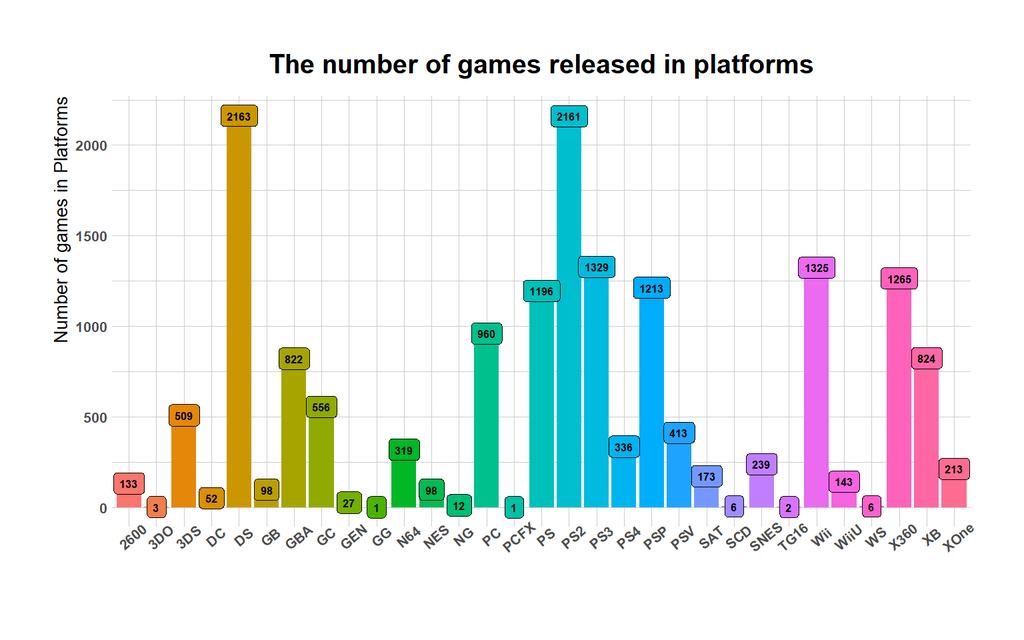

```r
data1 <- game %>% group_by(Platform) %>% summarise(Number_of_Games= n()) %>% arrange(desc(Number_of_Games))

data1 %>% ggplot(aes(x = Platform, y = Number_of_Games, fill = Platform)) +
  geom_bar(stat = "identity") +
  geom_label(mapping = aes(label = Number_of_Games), size = 2.2, fontface = "bold") +
  xlab("") +
  ylab("Number of games in Platforms") +
  ggtitle("The number of games released in platforms") +
  theme_ipsum() +
  theme(legend.position = "none",
        plot.title = element_text(size = 15, face = "bold", hjust = .5),
        axis.text.x = element_text(size = 8, face = "bold", angle = 40),
        axis.text.y = element_text(size = 8, face = "bold"),
        axis.title.y = element_text(size = 10))
```

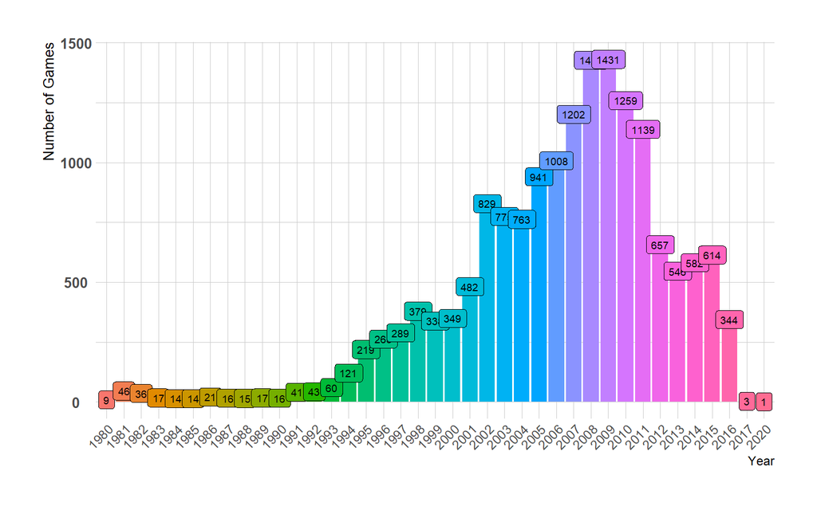

```r
number_of_games_per_platform <- game %>% filter(Year != "N/A") %>% group_by(Year) %>% summarise(Number_of_Games= n())

ggplot(number_of_games_per_platform, aes(x = Number_of_Games, y = Year, fill = Year)) +
  coord_flip() +
  geom_bar(stat = "identity") +
  xlab("Number of Games")+
  geom_label(aes(label = Number_of_Games), size = 2.5) +
  theme_ipsum() +
  theme(legend.position = "none",
        plot.title = element_text(size = 15, face = "bold", hjust = .5),
        axis.text.x = element_text(size = 9, hjust = 1, angle = 45),
        axis.text.y = element_text(size = 10, face = "bold", hjust = .5),
        axis.title.y = element_text(size = 10))
```

The chart shows the trend of video games between 1980 and 2020. The booming time of this industry is from 1993 to 2005, when the growth rate of the games released increased dramatically. This is considered the expansion stage of the video game industry. Between 2006 and 2011, when this industry switched into maturity stage, the number of games released were very high, at above 1000 games annually. Especially, in 2008-2009, the figure for games released reached a peak at 1431. Then it became saturated and began to decrease. Specifically, the number of games in 2012 was at 657, which is 1.73 times lower than the previous period. Then, in 2013-2016 the new games fluctuated from 300 to 600. Especially, from 2017 to 2020, there are approximately only 1 new game released. There are 271 games we do not get the information of the years released.

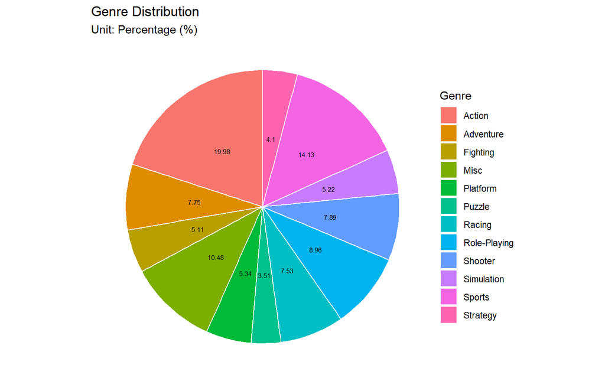

```r
genre_pie <- game %>% group_by(Genre) %>% summarise(counts = n()) %>%
  arrange(desc(Genre)) %>%
  mutate(prop = round(counts*100/sum(counts), 2), lab.ypos = cumsum(prop) - 0.5*prop)

genre_pie %>% ggplot(aes(x = "", y = prop, fill = Genre)) +
  geom_bar(width = 1, stat = "identity", color = "white") +
  geom_text(aes(y = lab.ypos, label = prop), size= 2.3)+
  coord_polar("y", start = 0)+
  theme_ipsum() +theme_void()+
  labs(title = "Genre Distribution", subtitle = "Unit: Percentage (%)")
```

Among more than 16,000 games, 19.98% are Action games, accounting for the most popular genre. The proportions of Sports and Misc games are 14.13% and 10.48%, respectively. Following by this is the Role-playing genre with 1488 games, making up for 8.96%. Shooter, Adventure, and Racing together comprise above 7%. Puzzle is considered the least popular genre with only 582 games, with the percentage of 3.51% of the total games.

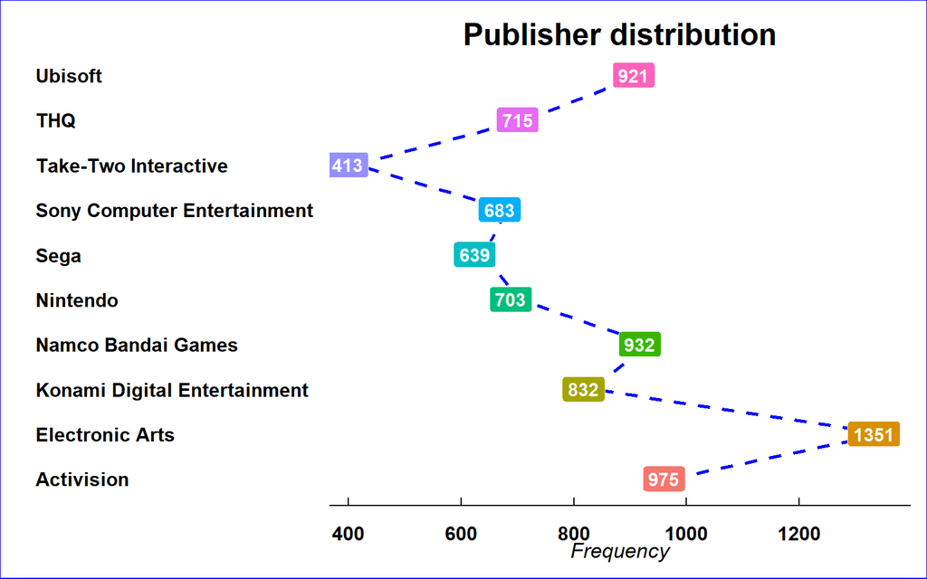

```r
freq_published <- data.frame(cbind(Frequency = table(game$Publisher), Percent = prop.table(table(game$Publisher)) * 100))
freq_published <- head(freq_published[order(freq_published$Frequency, decreasing = T), ], 10)
options(repr.plot.width = 14, repr.plot.height = 10)
ggplot(data = freq_published, mapping = aes(x = Frequency, y = row.names(freq_published))) +
  geom_line(group = 1, size = 1, color = "blue", linetype = "dashed") +
  geom_label(mapping = aes(label=Frequency, fill = row.names(freq_published)), size = 4, color = "white", fontface = "bold", hjust=.7) +
  ggtitle("Publisher distribution") +
  xlab("Frequency") +
  ylab("") +
  theme_economist() +
  theme(plot.background = element_rect(fill = "white", color = "blue"),
        plot.title = element_text(size = 19, hjust = .5, face = "bold"),
        axis.title.x = element_text(size = 13, hjust = .5, face = "italic"),
        axis.title.y = element_text(size = 13, hjust = .5, face = "italic"),
        axis.text.x = element_text(size = 12, face = "bold"),
        axis.text.y = element_text(size = 12, face = "bold"),
        legend.position = "none")
```

## 3. Handling data

### a. Handling missing and non-logical data

We assess the data is quite good, and only contains two small flaws. First, we see that there are only 16,598 observations while the rank values are from 1 to 16,600. By directly observing, we found out that the values 654 and 14,200 are missing. Hence, after sorting the global sales in descending, we decided to replace the ranking variable by new_ranking variable. Second, there are 271 NA (Not available) values in the “Year” variable. There are two ways to deal with this situation, consisting of deleting the observations or replacing the missing values. However, Year is a categorical variable; thus, we will get rid of all the missing data.

```r
game_new <- game %>%  arrange(desc(Global_Sales)) %>% mutate(Rank_New = 1:16598)
Year_game = as.numeric(game$Year)
summary(Year_game)
```

```
##    Min. 1st Qu.  Median    Mean 3rd Qu.    Max.    NA's
##    1980    2003    2007    2006    2010    2020     271
```

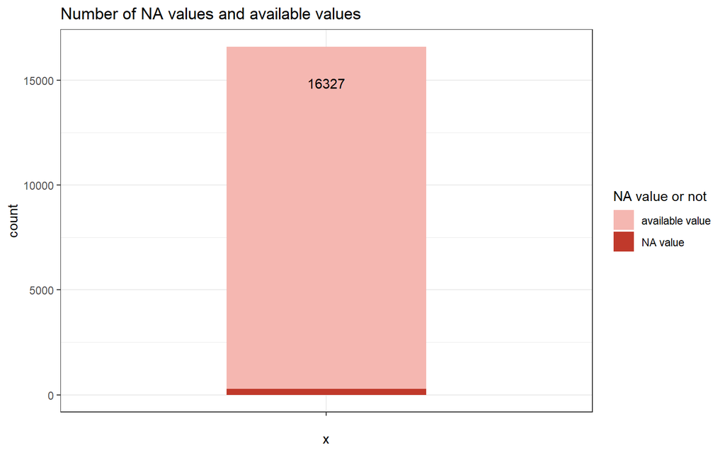

```r
NA_value <- c(rep("NA value",271), rep("available value",16327))
data2 <- game %>% mutate(NA_value)
data2 %>% ggplot(aes(x="",fill= NA_value))+
  geom_bar(width=0.45, stat='count')+
  stat_count(geom="text",aes(label = stat(count)),vjust=4)+
  scale_fill_manual(values= c("#F5B7B1","#C0392B"))+
  theme_bw()+
  labs(fill="NA value or not", title = "Number of NA values and available values")
```

### b. Handling outliers

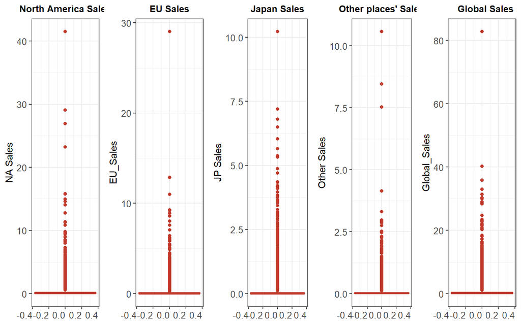

```r
box1<-ggplot(game, aes(NA_Sales)) +
  geom_boxplot(col = '#C0392B') +
  xlab("NA Sales")+coord_flip() +
  theme_bw() +
  labs(title = "North America Sales") +
  theme(axis.text = element_text(size=10,hjust=1),
        axis.title.x = element_text(size=10),
        plot.title = element_text(size=10,face="bold",hjust = 0.5),
        legend.key.size = unit(1, 'cm'))

box2<-ggplot(game, aes(EU_Sales)) +
  geom_boxplot(col = '#C0392B')+
  xlab("EU_Sales")+coord_flip() +
  theme_bw() +
  labs(title = "EU Sales")+
  theme(axis.text = element_text(size=10,hjust=1),
        axis.title.x = element_text(size=10),
        plot.title = element_text(size=10,face="bold",hjust = 0.5),
        legend.key.size = unit(1, 'cm'))

box3<-ggplot(game, aes(JP_Sales))+
  geom_boxplot(col = '#C0392B')+
  xlab("JP Sales")+coord_flip() +
  theme_bw() +
  labs(title = "Japan Sales")+
  theme(axis.text = element_text(size=10,hjust=1),
        axis.title.x = element_text(size=10),
        plot.title = element_text(size=10,face="bold",hjust = 0.5),
        legend.key.size = unit(1, 'cm'))

box4<-ggplot(game, aes(Other_Sales)) +
  geom_boxplot(col = '#C0392B') +
  xlab("Other Sales")+coord_flip() +
  theme_bw() +
  labs(title = "Other places' Sales") +
  theme(axis.text = element_text(size=10,hjust=1),
        axis.title.x = element_text(size=10),
        plot.title = element_text(size=10,face="bold",hjust = 0.5),
        legend.key.size = unit(1, 'cm'))

box5<-ggplot(game, aes(Global_Sales)) +
  geom_boxplot(col = '#C0392B') +
  xlab("Global_Sales")+coord_flip() +
  theme_bw() +
  labs(title = "Global Sales") +
  theme(axis.text = element_text(size=10,hjust=1),
        axis.title.x = element_text(size=10),
        plot.title = element_text(size=10,face="bold",hjust = 0.8),
        legend.key.size = unit(1, 'cm'))
grid.arrange(box1,box2,box3,box4,box5,ncol=5)
```

As can be seen from the boxplots, there are many outliers existing. To tackle outliers, we can delete them, or replace them with suitable values. For example, in terms of replacing, we can replace the high outliers by maximum value or low outliers by minimum. However, in our case, we do not run any models, and just visualize the dataset. Moreover, the outliers are still logical; thus, we decide to ignore them.

# III. Data Visualization

## 1. Sales

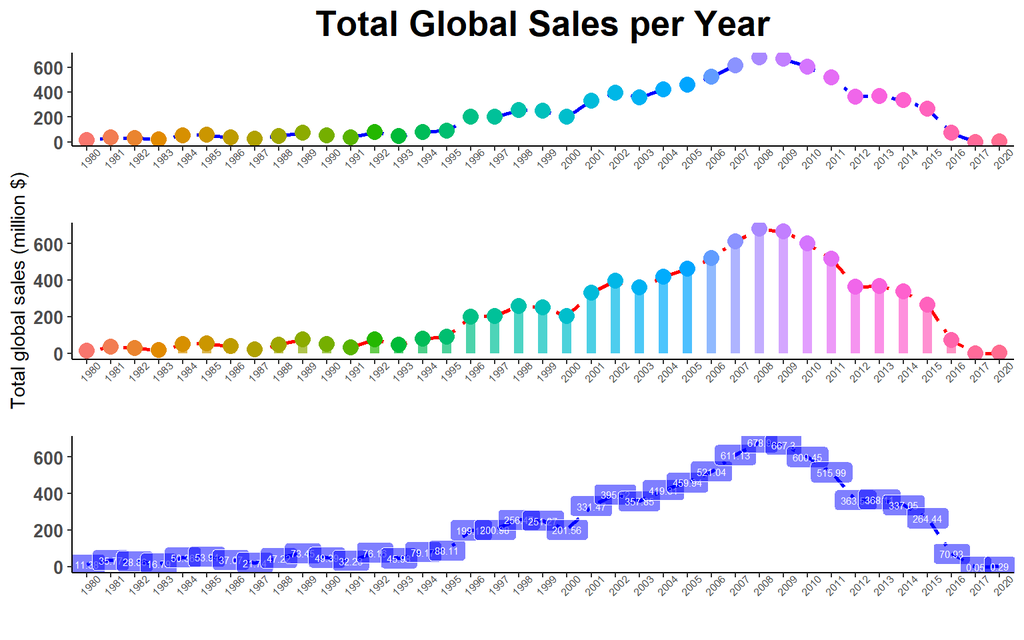

```r
total_global_sales_per_year <- game %>% group_by(Year) %>% summarise(Total_Global_Sales = sum(Global_Sales, na.rm = TRUE)) %>% filter(Year != 'N/A')

a <- ggplot(total_global_sales_per_year, aes(x = Year, y = Total_Global_Sales, color = Year)) +
  geom_line(color = 'blue', linetype = 10, size = 1, group = 1) +
  geom_point(shape = 20, size = 6) +
  xlab("") +
  ylab("") +
  ggtitle("Total Global Sales per Year") +
  theme_classic() +
  theme(legend.position = "none",
        plot.title = element_text(size = 20, face = "bold", hjust = 0.5),
        axis.text.x = element_text(size = 6, angle=45),
        axis.text.y = element_text(size = 10, face = "bold"))
b <- ggplot(total_global_sales_per_year, aes(x = Year, y = Total_Global_Sales, color = Year)) +
  geom_line(color = "red", linetype = 10, size = 1, group = 1) +
  geom_point(shape = 20, size = 6) +
  geom_segment(aes(xend = Year, yend = 0, color = Year), size = 2.5, alpha = 0.7) +
  xlab("") +
  ylab("Total global sales (million $)") +
  theme_classic() +
  theme(legend.position = "none",
        plot.title = element_text(size = 20, face = "bold", hjust = 0.5),
        axis.text.x = element_text(size = 6, angle=45),
        axis.text.y = element_text(size = 10, face = "bold"))
c <- ggplot(total_global_sales_per_year, aes(x = Year, y = Total_Global_Sales, color = Year)) +
  geom_line(color = "blue", linetype = 10, size = 1, group = 1) +
  geom_label(aes(label = Total_Global_Sales), fill = "blue", alpha = 0.5, size = 2, color = "white") +
  xlab("") +
  ylab("") +
  theme_classic() +
  theme(legend.position = "none",
        plot.title = element_text(size = 20, face = "bold", hjust = 0.5),
        axis.text.x = element_text(size = 6, angle=45),
        axis.text.y = element_text(size = 10, face = "bold"))
plot_grid(a, b, c, ncol = 1, nrow = 3)
```

The graphs above showed the trend in the global total sales of video games throughout the 40 - year - period. As can be seen, there has been a fluctuation in the gross revenue of this industry. Based on the growing and declining pattern of the overall sales, we may separate the development trend of this field into 3 sections for processing and assessment. The first section is the mild growth, which started from 1980 to 1995, next is the booming period, starting from 1995 to 2008, and finally is the regression one, which occurred from 2008 to 2020.

The year period from 1980 to 1995 experienced a slow growth rate in the number of sales despite the fact that during this time this is a The Tech Advancement Race stage (1985–2000). The reason can be explained by this is that the gaming industry grew too quickly to satisfy the customer demand. Eager to capitalize on a growing home console market, many publishers licensed extremely high-budget ports of games and quickly rushed them to market, released in poor quality, and cost the company millions in returns and more in brand damage. The variation of the trend in total sales during this period occurred frequently as the efforts of many companies investing in this potential industry.

```r
Continent <- c("North America", "Europe", "Japan", "Others", "Global")
Mean <- c(mean(NA_Sales), mean(EU_Sales), mean(JP_Sales), mean(Other_Sales), mean(Global_Sales))
mean_of_sales_by_continent <- data.frame(Continent, Mean)
mean_of_sales_by_continent
```

```
##       Continent       Mean
## 1 North America 0.26466743
## 2        Europe 0.14665201
## 3         Japan 0.07778166
## 4        Others 0.04806302
## 5        Global 0.53744066
```

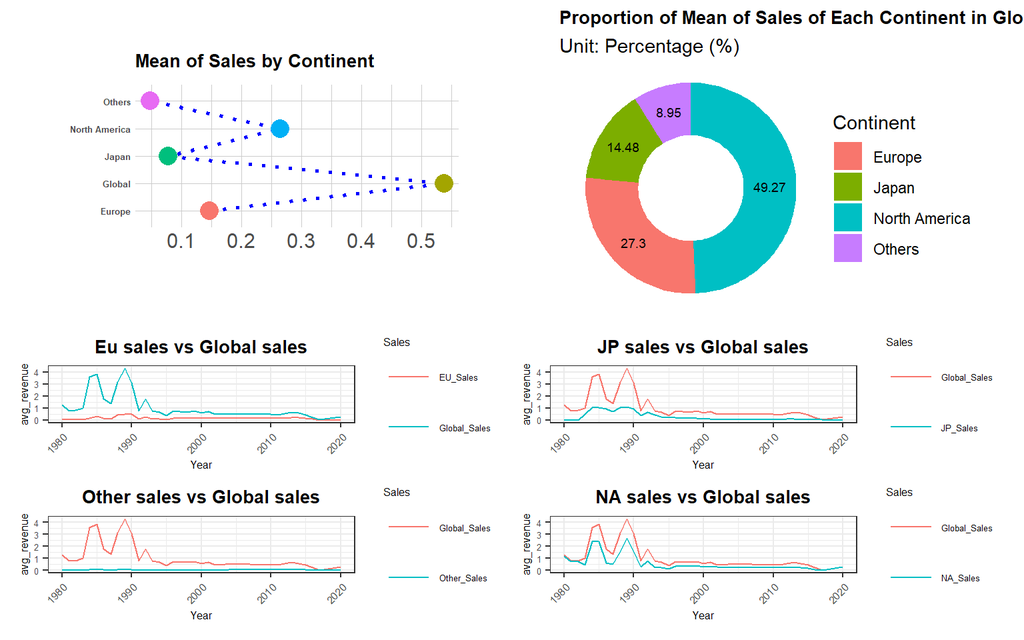

```r
a <- ggplot(mean_of_sales_by_continent, aes(x = Continent, y = Mean, group = 1)) + coord_flip() +
  geom_line(color = "blue", linetype = 15, size = 1) +
  geom_point(aes(color = Continent, size = 3)) + xlab("") + ylab("") +
  ggtitle("Mean of Sales by Continent") +
  theme_ipsum() +
  theme(legend.position = "none",
        plot.title = element_text(size = 10, face = "bold"),
        axis.title.x = element_text(size = 10, face = "bold"),
        axis.text.y = element_text(size = 5, face = "bold"))

proportion_of_mean_of_sales_of_each_continent_in_global_sales <- mean_of_sales_by_continent %>% head(4)
proportion_of_mean_of_sales_of_each_continent_in_global_sales$fraction <-
  proportion_of_mean_of_sales_of_each_continent_in_global_sales$Mean / sum(proportion_of_mean_of_sales_of_each_continent_in_global_sales$Mean)*100
proportion_of_mean_of_sales_of_each_continent_in_global_sales$ymax <- cumsum(proportion_of_mean_of_sales_of_each_continent_in_global_sales$fraction)
proportion_of_mean_of_sales_of_each_continent_in_global_sales$ymin <- c(0,
                                                                        head(proportion_of_mean_of_sales_of_each_continent_in_global_sales$ymax, n=-1))
proportion_of_mean_of_sales_of_each_continent_in_global_sales$labelPosition <-
  (proportion_of_mean_of_sales_of_each_continent_in_global_sales$ymax+proportion_of_mean_of_sales_of_each_continent_in_global_sales$ymin)/2
b <- ggplot(proportion_of_mean_of_sales_of_each_continent_in_global_sales, aes(xmin = 3, xmax = 4,
                                                                          ymin = ymin, ymax = ymax, fill = Continent)) +
  geom_rect() +
  geom_text(x = 3.5, aes(y = labelPosition, label = round(fraction, 2)), size = 2.5) +
  coord_polar(theta = "y") + xlim(c(2,4)) +
  theme_void() +
  ggtitle("Proportion of Mean of Sales of Each Continent in Global Sales",
          subtitle = "Unit: Percentage (%)") +
  theme(plot.title = element_text(size = 10, face = "bold"))

game$Year = as.numeric(game$Year)
sales_compare_plot <- function(title, ...) {
  game %>%
    filter(Year != "N/A") %>%
    dplyr::select(Year, ..., ...) %>%
    gather(Sales, Revenue, -Year) %>%
    group_by(Year, Sales) %>%
    mutate(avg_revenue = mean(Revenue)) %>%
    ggplot(aes(Year, avg_revenue, fill = Sales, group=Sales)) +
    geom_line(aes(color = Sales)) +
    labs(title = title) +
    theme_bw()+
    theme(axis.text.x = element_text(size = 6, hjust = 1, angle = 45),
          plot.title = element_text(size = 10, face="bold", hjust = 0.5),
          text = element_text(size = 6),
          legend.key.size = unit(1, 'cm')) }
options(repr.plot.width = 15, repr.plot.height = 10)
c <- (sales_compare_plot("Eu sales vs Global sales", EU_Sales, Global_Sales) +
    sales_compare_plot("JP sales vs Global sales", JP_Sales, Global_Sales)) /
  (sales_compare_plot("Other sales vs Global sales", Other_Sales, Global_Sales) + sales_compare_plot("NA sales vs Global sales", NA_Sales, Global_Sales))

plot_grid(plot_grid(a, b, ncol = 2, nrow = 1), c, ncol =1, nrow = 2)
```

The six graphs above depicted the average sales of the mentioned continents, Japan and other countries. Overall, statistics reveal that North America has the highest average sales, followed by Europe, Japan, and the rest of the world.

Looking at the pie chart on the right, we can see that North America accounts for the majority of sales, accounting for 49.27 percent internationally, more than 1.5 times that of the second-ranked continent. Consumption was placed second with European nations contributing around 27.3 percent of total global consumption. Japan is third in total world consumption, accounting for up to 14.48 percent of total world consumption. It can be observed that Japanese customers alone consume a considerable share of the world’s video game consumption. The remaining nations are placed last, contributing to the globe at a rate of 8.95 percent of the overall world.

When comparing the sales of each location to the overall sales globally, the four following graphs provide a more thorough view about the sales throughout the years. Overall, as shown in the charts, the majority of the trend models of the chosen places for comparison tend to rise and drop in accordance with the pattern of the global trend, except for the other nations, where the increase is not much decreased. In general, the graph’s development history shows that worldwide sales boomed from the 1980s to the 1990s, then declined in the following years until bottoming out in 2017. More precisely, in comparison with the worldwide video game sales, the Europe sales volume has fluctuated considerably the last 40 years. When compared to the worldwide trend model, Japan’s sales volume fluctuates vast. Furthermore, Japan’s gain and loss margin were greater than the EU’s. Comparing North American sales to total global sales, we can observe that North American sales fluctuate more than Japan’s in response to global ups and downs. According to the worldwide trend, the graph pattern varies pretty dramatically.

## 2. Platform

### a. Total recorded sales vs platforms

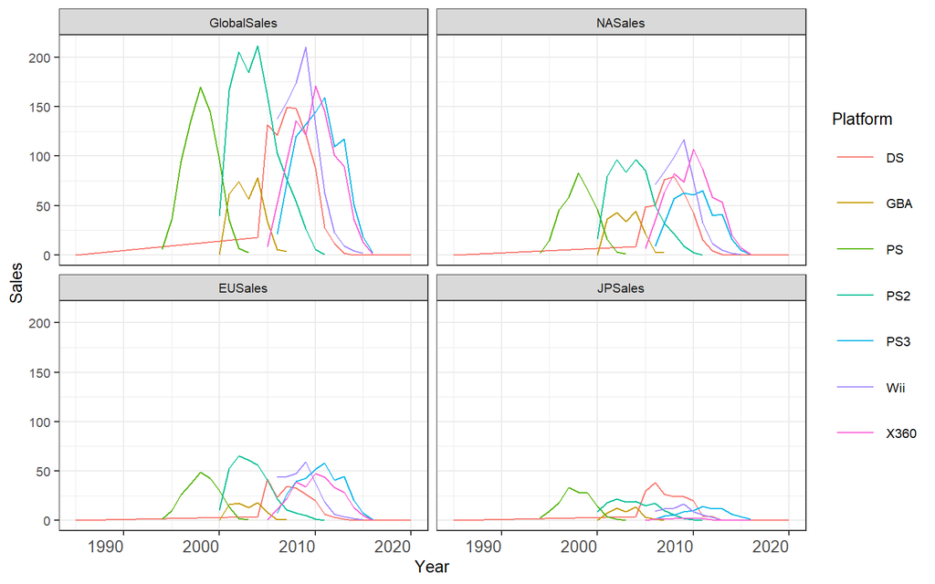

```r
data1 <- game %>%filter(Year != "N/A") %>% group_by(Platform) %>% mutate(Number_of_Game= n()) %>% arrange(desc(Number_of_Game)) %>% ungroup()
top7_sales_platform <- data1 %>% group_by(Platform) %>% dplyr::summarise(GlobalSales=sum(Global_Sales)) %>% arrange(desc(GlobalSales)) %>% head(7)

sales_by_platform <- data1 %>% filter(Platform %in% top7_sales_platform$Platform) %>% group_by(Platform, Year) %>%
summarise(GlobalSales = sum(Global_Sales), NASales = sum(NA_Sales), EUSales = sum(EU_Sales), JPSales = sum(JP_Sales))

sales_by_platform = melt(sales_by_platform, id=c("Platform", "Year"))
colnames(sales_by_platform) = c("Platform", "Year", "SalesType", "Sales")

sales_by_platform$Year = as.numeric(sales_by_platform$Year)

ggplot(sales_by_platform, aes(x = Year, y = Sales, colour = Platform, group = Platform)) +
  geom_line()+
  facet_wrap(~SalesType) +
  ylab("Sales") +
  theme_bw()+
  theme(axis.text.x = element_text(size=10,hjust=1),
        plot.title = element_text(size=20,face="bold",hjust = 0.5),
        text = element_text(size = 10),
        legend.key.size = unit(1, 'cm'))
```

The line chart reflected the overall pattern in video game sales in terms of geographical region. Overall, after experiencing a sales increase, all of these lines had a drop in sales. From a worldwide standpoint, the PS2 and WII had the highest overall sales when compared to other competitors. GBA was the smallest donor. A second study revealed that platform dominance varied with segmentation.

In terms of North America, the Wii and X360 were the two most popular platforms. Following that is the PS2, which has a very high statistic. As shown in the chart, despite entering the market quite late in comparison to other rivals who had previously departed, the Wii had a highly good response from North American gamers.

### b. Number of games released over the years per platform

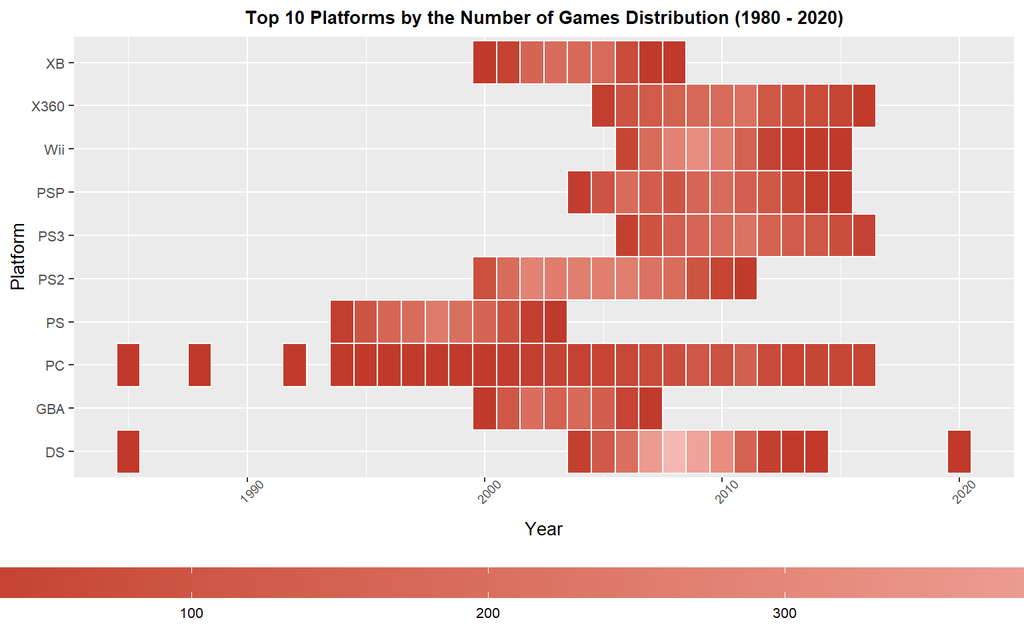

```r
top_10_platforms_by_the_number_of_games <- game %>% group_by(Platform) %>% summarise(Number_of_Game = n())%>%
  arrange(desc(Number_of_Game)) %>% head(10)
top_10_platforms_by_the_number_of_games_distribution <- game %>% filter(Platform %in% top_10_platforms_by_the_number_of_games$Platform) %>%
  filter (Year != "N/A") %>% group_by(Platform, Year) %>%
  summarise(Number_of_Games = n())

ggplot(top_10_platforms_by_the_number_of_games_distribution, aes(Year, Platform, fill = Number_of_Games)) +scale_fill_gradient(low ="#C0392B" , high = "#F5B7B1")+
  geom_tile(color = "white", size = 0.5)+
  theme(axis.text.x = element_text(size = 7, angle = 45, hjust = 0.5),
        plot.title = element_text(size = 10, hjust = 0.5, face = 'bold'),
        legend.position = "bottom",
        text = element_text(size = 10),
        legend.key.width = unit(5.8, "cm"))+
  ggtitle("Top 10 Platforms by the Number of Games Distribution (1980 - 2020)")
```

## 3. Year

### a. Number of games released per year vs Sales per year

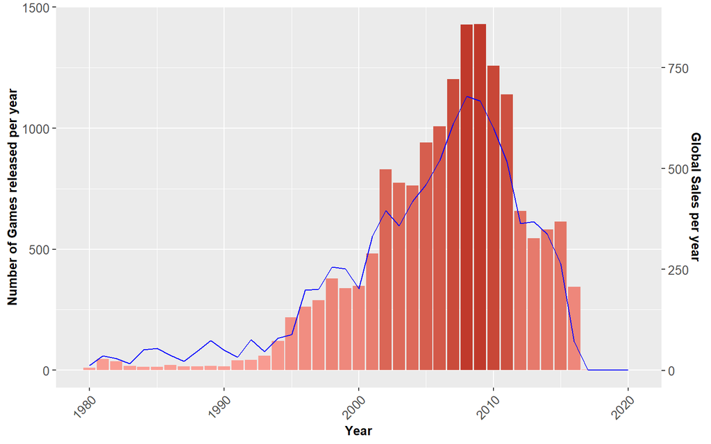

```r
data1 <- game %>% filter(Year != "N/A") %>% group_by(Year) %>% summarise(Number_of_Game=n(), GlobalSales=sum(Global_Sales))
data1 %>% ggplot(aes(x=Year)) +
  geom_bar(aes(y= Number_of_Game, fill= Number_of_Game), stat="identity") +
  scale_fill_gradient(low = "#fa9f96", high = "#C0392B") +
  geom_line(aes(x=Year, y= GlobalSales/0.6), group=1, inherit.aes = FALSE, color= "blue") +
  scale_y_continuous(name= "Number of Games released per year",
                     sec.axis=sec_axis(trans=~.*0.6, name="Global Sales per year")) +
  theme(axis.text.x = element_text(size=10,hjust=1, angle =45),
        axis.text.y = element_text(size=10),
        axis.title = element_text(size=10, face="bold"),
        legend.position = "none",
        plot.title = element_text(size=12,face="bold",hjust = 0.5),
        text = element_text(size = 8),legend.key.size = unit(1, 'cm'))
```

The last stage was regression. During this time, the overall number of games published to the market decreased substantially, affecting the industry’s gross income.

### b. Best Global Sales Game per Year

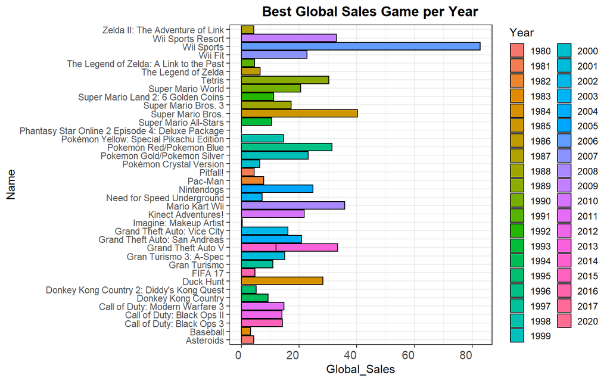

```r
game1 <- game
game1$Year <- as.factor(Year)
game1 %>% group_by(Year) %>% filter(Year!="N/A") %>%
  arrange(desc(Global_Sales)) %>%
  top_n(1) %>%
  ggplot(aes(x = Global_Sales, y = Name, fill = Year)) +
  geom_bar(stat = 'identity', colour = 'black') +
  ggtitle('Best Global Sales Game per Year') +
  theme_bw() +
  theme(axis.text.x = element_text(size = 11, hjust= 1),
        plot.title = element_text(size = 13, face = "bold", hjust = 0.7),
        text = element_text(size = 11),
        legend.key.size = unit(0.5, 'cm'))
```

As originally indicated, we may divide the growth trend of this sector into three groups for processing and assessment. The first portion covers the modest expansion phase, which lasted from 1980 to 1995, followed by the booming period, which lasted from 1995 to 2008, and lastly the decline period, which lasted from 2008 to 2020.  
From 1980 through 1995, independent games like Super Mario Bros 3, Tetris, and Duck Hunt dominated the stage. Duck Hunt and the launch of Mario in Super Mario Bros resurrected the console market.

From 1995 to 2008, there was a shift in consumer behavior as sports games flourished, thanks to the launching of Wii Sports by the Wii publisher. This explains why, despite being a new competitor in this area, the Wii has received a warm welcome in all regions. The Pokemon game series, as well as role-playing games like Grand Theft Auto, were popular at the time.

From 2008 to 2020, role-playing and action games grew in popularity and development. Despite this, independent games like Mario Kart Wii have received a lot of attention. Because of changes in customer behavior tendencies, sales of Call of Duty and Grand Theft Auto V began to rise.

## 4. Genre

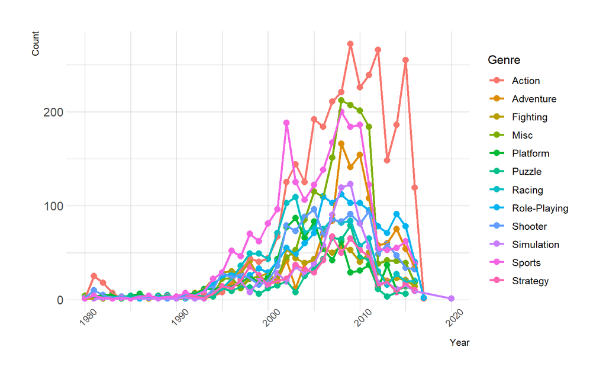

```r
game_count_by_genre_per_year <- game %>%
  group_by(Year, Genre) %>%
  dplyr::summarize(Count = n())

ggplot(game_count_by_genre_per_year, aes(x = Year, y = Count, color = Genre, group = Genre)) +
  geom_point(size = 2.5) + geom_line(size = 1) + theme_ipsum() +
  theme(axis.text.x = element_text(size = 9, angle = 45))
```

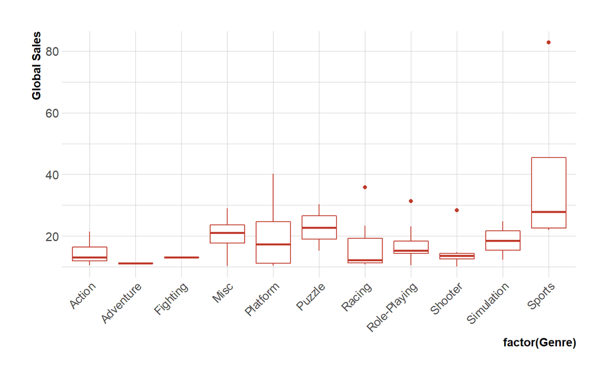

```r
global_sales_platform_boxplot <- game %>% filter(Global_Sales>10.0)
ggplot(global_sales_platform_boxplot, aes(x = factor(Genre), y = Global_Sales), fill = Genre)+
  geom_boxplot(col = '#C0392B')+
  ylab("Global Sales")+
  theme_ipsum()+
  theme(axis.text.x = element_text(size=11,hjust=1, angle=45),
        axis.title.x = element_text(size=11, face="bold"),
        axis.title.y = element_text(size=11, face="bold"),
        text = element_text(size = 10),
        legend.key.size = unit(1, 'cm'))
```

## 5. Publisher

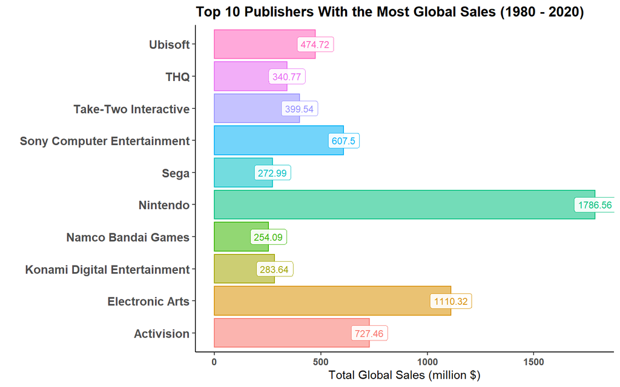

```r
top_10_publishers_with_the_most_sales <- game %>% group_by(Publisher) %>%
  summarise(Total_Sales = sum(Global_Sales)) %>% arrange(desc(Total_Sales)) %>% head(10)

ggplot(top_10_publishers_with_the_most_sales, aes(x = Publisher, y = Total_Sales, color = Publisher)) +
  geom_bar(stat = "identity", aes(fill = Publisher, alpha = 0.7)) +
  geom_label(aes(label = Total_Sales), size = 3, alpha = 0.9) +
  ggtitle("Top 10 Publishers With the Most Global Sales (1980 - 2020)") +
  xlab("") + ylab("Total Global Sales (million $)") + coord_flip() +
  theme_classic() +
  theme(legend.position = "none",
        plot.title = element_text(size = 13, face = "bold"),
        axis.text.x = element_text(size = 9, face = "bold"),
        axis.text.y = element_text(size = 11, face = "bold"))
```

The animation figure below will specifically describe the sales of top 5 publishers between 1980 to 2020:

[figure not shown]

```r
top_5_publishers_with_the_most_sales <- top_10_publishers_with_the_most_sales %>% head(5)
top_5_publishers_with_the_most_sales_growth <- game %>% filter(Publisher %in% top_5_publishers_with_the_most_sales$Publisher) %>% filter(Year != "N/A")
top_5_publishers_with_the_most_sales_growth$Year = as.numeric(top_5_publishers_with_the_most_sales_growth$Year)
anim <- ggplot(top_5_publishers_with_the_most_sales_growth, aes(x = Year, y = Global_Sales, color = Publisher, group = Publisher)) +
  geom_line(size = 0.9) +
  ggtitle("Top 5 Publisher with the Most Global Sales Growth (1980 - 2020)") +
  theme_classic() +
  xlab("") + ylab("Global Sales") +
  theme(axis.text.x = element_text(size=12,hjust=1,angle=45),
        axis.text.y = element_text(size=12,hjust=1),
        plot.title = element_text(size=16,face="bold",hjust = 0.5),
        text = element_text(size = 12),
        axis.title.y = element_text(size = 12),
        legend.text = element_text(size = 12),
        legend.key.size = unit(1, 'cm')) +
  geom_point(size = 2.4) +
  transition_reveal(Year)

animate(anim,nframes=120, width=800, height=600, renderer = gifski_renderer())
```